# Comparison of Liftoff Results: Brian v1.0 vs ICSASG_v2 to Ssal_v3.1

Gene ID Mapping Project

2026-01-30

# Overview

This analysis compares gene annotation mapping results from two different Atlantic salmon assemblies lifted to the Ssal_v3.1 assembly:

1. **Ssal_Brian_v1.0** lifted to Ssal_v3.1 Ensembl
2. **ICSASG_v2** Ensembl lifted to Ssal_v3.1 Ensembl

Both liftoff outputs are compared against the native Ssal_v3.1 Ensembl annotation using `within_assembly_compare.py`. The goal is to assess which source assembly produces better annotation mapping to Ssal_v3.1.

# Load Libraries and Data

```r
library(tidyverse)
library(knitr)
library(kableExtra)
library(scales)

# Set color palette for classification
class_colors <- c(
  "Green" = "#4CAF50",
  "Yellow" = "#FFEB3B",
  "Red" = "#F44336",
  "NotMapped" = "#9E9E9E"
)

class_order <- c("Green", "Yellow", "Red", "NotMapped")
```

```r
# Load Brian v1.0 comparison
brian_file <- "../experiments/comparison_runs/brian_lift_vs_native.tsv"
brian_raw <- read_tsv(brian_file, col_types = cols())

# Load ICSASG_v2 comparison
icsasg_file <- "../experiments/comparison_runs/ens_lift_vs_native.tsv"
icsasg_raw <- read_tsv(icsasg_file, col_types = cols())

# Function to parse stats column
parse_stats <- function(df) {
  # Filter for gene-level entries only
  genes <- df %>% filter(feature == "gene")

  # Parse the stats column
  stats_parsed <- genes %>%
    separate_rows(stats, sep = ";") %>%
    filter(str_detect(stats, "=")) %>%
    separate(stats, into = c("key", "value"), sep = "=", extra = "merge") %>%
    pivot_wider(names_from = key, values_from = value, values_fn = first)

  # Convert numeric columns
  numeric_cols <- c("best_jaccard_exon", "best_jaccard_cds_phase",
                    "overlap_bp", "exon_union_bp", "partner_countA",
                    "partner_countB", "strand_match")

  for (col in numeric_cols) {
    if (col %in% names(stats_parsed)) {
      stats_parsed[[col]] <- as.numeric(stats_parsed[[col]])
    }
  }

  # Extract stable IDs
  stats_parsed <- stats_parsed %>%
    mutate(
      stableA = str_extract(geneA, "ENSSSAG[0-9]+"),
      stableB = str_extract(geneB, "ENSSSAG[0-9]+"),
      stable_same = stableA == stableB,
      class = factor(class, levels = class_order)
    )

  return(stats_parsed)
}

# Parse both datasets
brian_genes <- parse_stats(brian_raw) %>% mutate(source = "Brian_v1.0")
icsasg_genes <- parse_stats(icsasg_raw) %>% mutate(source = "ICSASG_v2")

# Combine for comparison
combined <- bind_rows(brian_genes, icsasg_genes)
```

# Overall Statistics

```r
overall_summary <- combined %>%
  group_by(source) %>%
  summarise(
    total_genes = n(),
    .groups = "drop"
  )

kable(overall_summary,
      caption = "Total gene pairs compared in each liftoff",
      format.args = list(big.mark = ",")) %>%
  kable_styling(bootstrap_options = c("striped", "hover"))
```

Total gene pairs compared in each liftoff

| source | total_genes |
| --- | --- |
| Brian_v1.0 | 52,052 |
| ICSASG_v2 | 49,125 |

# Classification Comparison

## Classification Counts

```r
class_summary <- combined %>%
  group_by(source, class) %>%
  summarise(count = n(), .groups = "drop") %>%
  pivot_wider(names_from = class, values_from = count, values_fill = 0) %>%
  mutate(Total = Green + Yellow + Red + NotMapped)

kable(class_summary,
      caption = "Gene pair classifications by source assembly",
      format.args = list(big.mark = ",")) %>%
  kable_styling(bootstrap_options = c("striped", "hover"))
```

Gene pair classifications by source assembly

| source | Green | Yellow | Red | NotMapped | Total |
| --- | --- | --- | --- | --- | --- |
| Brian_v1.0 | 18,033 | 17,800 | 7,107 | 9,112 | 52,052 |
| ICSASG_v2 | 15,706 | 18,143 | 5,890 | 9,386 | 49,125 |

## Classification Percentages

```r
class_pct <- combined %>%
  group_by(source, class) %>%
  summarise(count = n(), .groups = "drop") %>%
  group_by(source) %>%
  mutate(
    percentage = count / sum(count) * 100,
    pct_label = sprintf("%.1f%%", percentage)
  ) %>%
  ungroup()

kable(class_pct %>%
        select(source, class, count, percentage) %>%
        arrange(source, class),
      caption = "Classification percentages by source",
      col.names = c("Source", "Class", "Count", "Percentage"),
      digits = 1,
      format.args = list(big.mark = ",")) %>%
  kable_styling(bootstrap_options = c("striped", "hover"))
```

Classification percentages by source

| Source | Class | Count | Percentage |
| --- | --- | --- | --- |
| Brian_v1.0 | Green | 18,033 | 34.6 |
| Brian_v1.0 | Yellow | 17,800 | 34.2 |
| Brian_v1.0 | Red | 7,107 | 13.7 |
| Brian_v1.0 | NotMapped | 9,112 | 17.5 |
| ICSASG_v2 | Green | 15,706 | 32.0 |
| ICSASG_v2 | Yellow | 18,143 | 36.9 |
| ICSASG_v2 | Red | 5,890 | 12.0 |
| ICSASG_v2 | NotMapped | 9,386 | 19.1 |

## Visualization: Classification Distribution

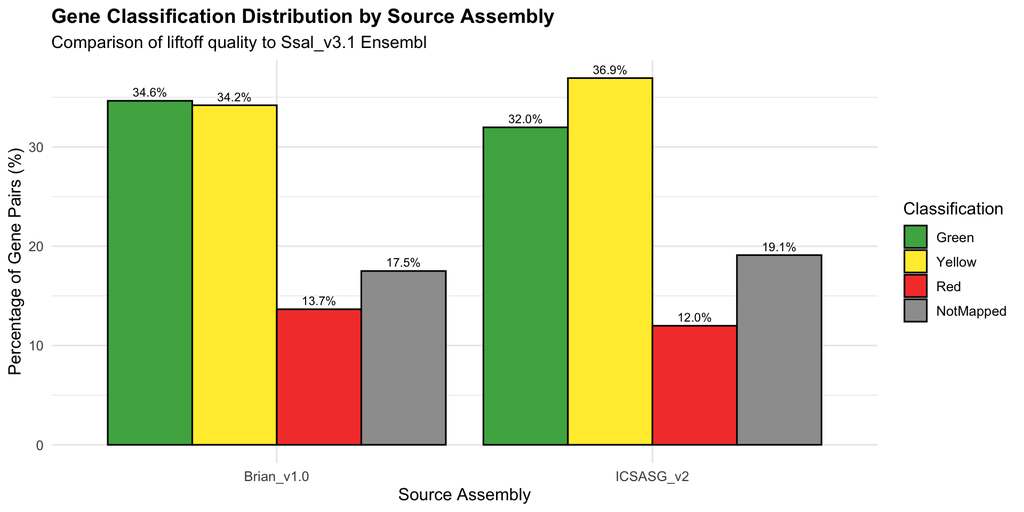

```r
ggplot(class_pct, aes(x = source, y = percentage, fill = class)) +
  geom_col(position = "dodge", color = "black", size = 0.3) +
  geom_text(aes(label = pct_label),
            position = position_dodge(width = 0.9),
            vjust = -0.5, size = 3) +
  scale_fill_manual(values = class_colors) +
  labs(
    title = "Gene Classification Distribution by Source Assembly",
    subtitle = "Comparison of liftoff quality to Ssal_v3.1 Ensembl",
    x = "Source Assembly",
    y = "Percentage of Gene Pairs (%)",
    fill = "Classification"
  ) +
  theme_minimal(base_size = 12) +
  theme(
    plot.title = element_text(face = "bold", size = 14),
    legend.position = "right"
  )
```

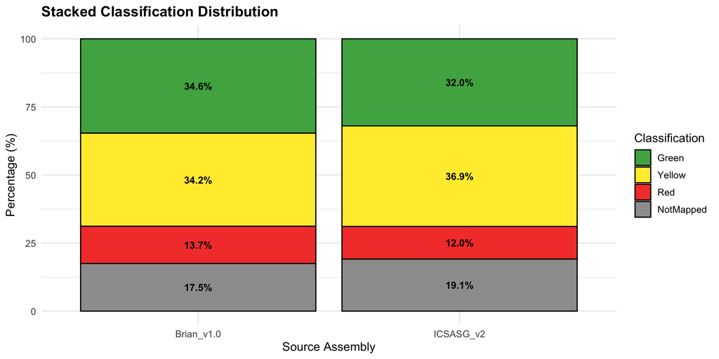

```r
ggplot(class_pct, aes(x = source, y = percentage, fill = class)) +
  geom_col(color = "black", size = 0.3) +
  geom_text(aes(label = pct_label),
            position = position_stack(vjust = 0.5),
            size = 3.5, fontface = "bold") +
  scale_fill_manual(values = class_colors) +
  labs(
    title = "Stacked Classification Distribution",
    x = "Source Assembly",
    y = "Percentage (%)",
    fill = "Classification"
  ) +
  theme_minimal(base_size = 12) +
  theme(plot.title = element_text(face = "bold"))
```

# Quality Metrics

## Jaccard Index Distributions

### CDS-Phase Jaccard

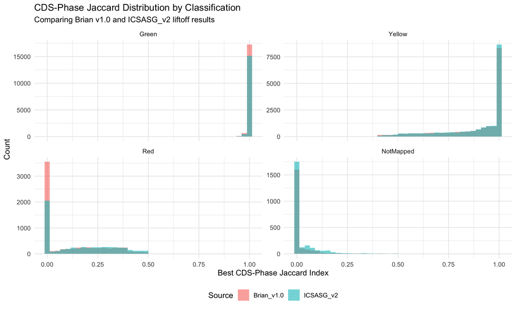

```r
ggplot(combined %>% filter(!is.na(best_jaccard_cds_phase)),
       aes(x = best_jaccard_cds_phase, fill = source)) +
  geom_histogram(bins = 40, alpha = 0.6, position = "identity") +
  facet_wrap(~class, scales = "free_y") +
  labs(
    title = "CDS-Phase Jaccard Distribution by Classification",
    subtitle = "Comparing Brian v1.0 and ICSASG_v2 liftoff results",
    x = "Best CDS-Phase Jaccard Index",
    y = "Count",
    fill = "Source"
  ) +
  theme_minimal() +
  theme(legend.position = "bottom")
```

### Exon Jaccard

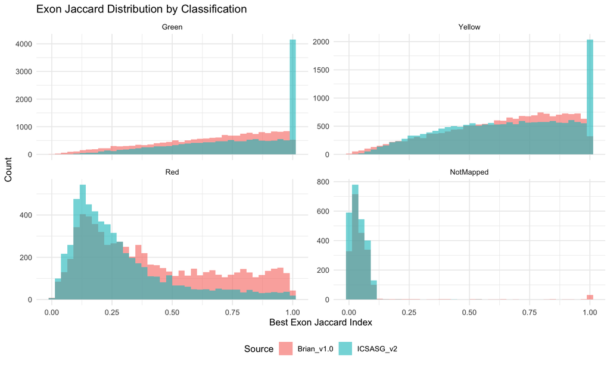

```r
ggplot(combined %>% filter(!is.na(best_jaccard_exon)),
       aes(x = best_jaccard_exon, fill = source)) +
  geom_histogram(bins = 40, alpha = 0.6, position = "identity") +
  facet_wrap(~class, scales = "free_y") +
  labs(
    title = "Exon Jaccard Distribution by Classification",
    x = "Best Exon Jaccard Index",
    y = "Count",
    fill = "Source"
  ) +
  theme_minimal() +
  theme(legend.position = "bottom")
```

## Summary Statistics by Classification

```r
quality_summary <- combined %>%
  filter(!is.na(best_jaccard_cds_phase) | !is.na(best_jaccard_exon)) %>%
  group_by(source, class) %>%
  summarise(
    n = n(),
    mean_cds_jaccard = mean(best_jaccard_cds_phase, na.rm = TRUE),
    median_cds_jaccard = median(best_jaccard_cds_phase, na.rm = TRUE),
    mean_exon_jaccard = mean(best_jaccard_exon, na.rm = TRUE),
    median_exon_jaccard = median(best_jaccard_exon, na.rm = TRUE),
    .groups = "drop"
  )

kable(quality_summary,
      caption = "Mean and median Jaccard indices by classification",
      digits = 3,
      format.args = list(big.mark = ",")) %>%
  kable_styling(bootstrap_options = c("striped", "hover", "condensed"))
```

Mean and median Jaccard indices by classification

| source | class | n | mean_cds_jaccard | median_cds_jaccard | mean_exon_jaccard | median_exon_jaccard |
| --- | --- | --- | --- | --- | --- | --- |
| Brian_v1.0 | Green | 18,033 | 0.999 | 1.000 | 0.658 | 0.701 |
| Brian_v1.0 | Yellow | 17,800 | 0.882 | 0.971 | 0.635 | 0.669 |
| Brian_v1.0 | Red | 7,017 | 0.120 | 0.004 | 0.419 | 0.350 |
| Brian_v1.0 | NotMapped | 2,009 | 0.021 | 0.000 | 0.064 | 0.037 |
| ICSASG_v2 | Green | 15,706 | 0.999 | 1.000 | 0.753 | 0.804 |
| ICSASG_v2 | Yellow | 18,143 | 0.887 | 0.976 | 0.653 | 0.672 |
| ICSASG_v2 | Red | 5,812 | 0.165 | 0.148 | 0.289 | 0.223 |
| ICSASG_v2 | NotMapped | 2,450 | 0.030 | 0.000 | 0.039 | 0.033 |

# Stable ID Agreement

Gene pairs where the stable Ensembl ID is preserved between source and target annotations.

```r
stable_summary <- combined %>%
  group_by(source, class, stable_same) %>%
  summarise(count = n(), .groups = "drop") %>%
  group_by(source, class) %>%
  mutate(
    percentage = count / sum(count) * 100
  ) %>%
  ungroup()

kable(stable_summary %>% arrange(source, class, stable_same),
      caption = "Stable ID agreement by classification",
      col.names = c("Source", "Class", "Stable ID Same", "Count", "Percentage"),
      digits = 1,
      format.args = list(big.mark = ",")) %>%
  kable_styling(bootstrap_options = c("striped", "hover"))
```

Stable ID agreement by classification

| Source | Class | Stable ID Same | Count | Percentage |
| --- | --- | --- | --- | --- |
| Brian_v1.0 | Green | FALSE | 18,033 | 100.0 |
| Brian_v1.0 | Yellow | FALSE | 17,800 | 100.0 |
| Brian_v1.0 | Red | FALSE | 7,107 | 100.0 |
| Brian_v1.0 | NotMapped | FALSE | 9,112 | 100.0 |
| ICSASG_v2 | Green | FALSE | 3,767 | 24.0 |
| ICSASG_v2 | Green | TRUE | 11,939 | 76.0 |
| ICSASG_v2 | Yellow | FALSE | 6,631 | 36.5 |
| ICSASG_v2 | Yellow | TRUE | 11,512 | 63.5 |
| ICSASG_v2 | Red | FALSE | 4,793 | 81.4 |
| ICSASG_v2 | Red | TRUE | 1,097 | 18.6 |
| ICSASG_v2 | NotMapped | FALSE | 9,332 | 99.4 |
| ICSASG_v2 | NotMapped | TRUE | 54 | 0.6 |

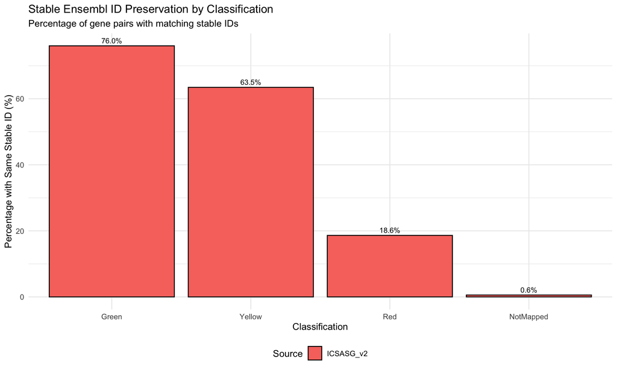

```r
ggplot(stable_summary %>% filter(stable_same),
       aes(x = class, y = percentage, fill = source)) +
  geom_col(position = "dodge", color = "black", size = 0.3) +
  geom_text(aes(label = sprintf("%.1f%%", percentage)),
            position = position_dodge(width = 0.9),
            vjust = -0.5, size = 3) +
  labs(
    title = "Stable Ensembl ID Preservation by Classification",
    subtitle = "Percentage of gene pairs with matching stable IDs",
    x = "Classification",
    y = "Percentage with Same Stable ID (%)",
    fill = "Source"
  ) +
  theme_minimal() +
  theme(legend.position = "bottom")
```

# Split/Merge Analysis

Genes that map to multiple partners (split/merge events).

```r
# Extract split/merge information
split_merge <- combined %>%
  mutate(
    has_split_merge_A = !is.na(note_split_or_merge_A),
    has_split_merge_B = !is.na(note_split_or_merge_B),
    has_split_merge = has_split_merge_A | has_split_merge_B
  )

split_summary <- split_merge %>%
  group_by(source, has_split_merge) %>%
  summarise(count = n(), .groups = "drop") %>%
  group_by(source) %>%
  mutate(percentage = count / sum(count) * 100)

kable(split_summary,
      caption = "Split/merge events by source",
      col.names = c("Source", "Has Split/Merge", "Count", "Percentage"),
      digits = 1,
      format.args = list(big.mark = ",")) %>%
  kable_styling(bootstrap_options = c("striped", "hover"))
```

Split/merge events by source

| Source | Has Split/Merge | Count | Percentage |
| --- | --- | --- | --- |
| Brian_v1.0 | FALSE | 27,950 | 53.7 |
| Brian_v1.0 | TRUE | 24,102 | 46.3 |
| ICSASG_v2 | FALSE | 23,571 | 48.0 |
| ICSASG_v2 | TRUE | 25,554 | 52.0 |

# Key Findings

```r
# Calculate key metrics for each source
findings <- combined %>%
  group_by(source) %>%
  summarise(
    total = n(),
    green_pct = sum(class == "Green") / n() * 100,
    yellow_pct = sum(class == "Yellow") / n() * 100,
    red_pct = sum(class == "Red") / n() * 100,
    notmapped_pct = sum(class == "NotMapped") / n() * 100,
    high_confidence = sum(class == "Green") / n() * 100,
    significant = sum(class %in% c("Green", "Yellow")) / n() * 100,
    mean_cds = mean(best_jaccard_cds_phase, na.rm = TRUE),
    mean_exon = mean(best_jaccard_exon, na.rm = TRUE),
    stable_id_match = sum(stable_same, na.rm = TRUE) / sum(!is.na(stable_same)) * 100
  )

kable(findings,
      caption = "Summary of key findings",
      digits = 1,
      format.args = list(big.mark = ",")) %>%
  kable_styling(bootstrap_options = c("striped", "hover"))
```

Summary of key findings

| source | total | green_pct | yellow_pct | red_pct | notmapped_pct | high_confidence | significant | mean_cds | mean_exon | stable_id_match |
| --- | --- | --- | --- | --- | --- | --- | --- | --- | --- | --- |
| Brian_v1.0 | 52,052 | 34.6 | 34.2 | 13.7 | 17.5 | 34.6 | 68.8 | 0.8 | 0.6 | 0.0 |
| ICSASG_v2 | 49,125 | 32.0 | 36.9 | 12.0 | 19.1 | 32.0 | 68.9 | 0.8 | 0.6 | 50.1 |

## Interpretation

Based on the analysis above:

1. **High Confidence (Green) Mappings**: Compare the percentage of Green classifications between Brian_v1.0 and ICSASG_v2. Higher percentages indicate better annotation preservation during liftoff.
2. **Overall Mapping Quality**: The sum of Green + Yellow classifications indicates the proportion of genes with significant mapping evidence.
3. **Mean Jaccard Indices**: Higher mean CDS and exon Jaccard indices suggest better structural alignment between lifted and native annotations.
4. **Stable ID Preservation**: Higher percentages indicate better gene identity preservation across assemblies.
5. **Split/Merge Events**: Fewer split/merge events typically indicate cleaner one-to-one gene mappings.

# Conclusion

This analysis provides a comprehensive comparison of how well annotations from two different Atlantic salmon assemblies (Brian_v1.0 and ICSASG_v2) transfer to the Ssal_v3.1 assembly via Liftoff. The metrics help determine which source assembly provides better annotation continuity for Salmobase integration.

**Analysis generated**: 2026-01-30 12:14:18.134791